# Data Science - Regressão Linear

# Conhecendo o Dataset

## Importando bibliotecas

https://matplotlib.org/

https://pandas.pydata.org/

http://www.numpy.org/

```python
import matplotlib.pyplot as plt
%matplotlib inline

import pandas as pd
import numpy as np
```

## Bibliotecas opcionais

https://docs.python.org/3/library/warnings.html

```python
import warnings

warnings.filterwarnings('ignore') # ou warnings.filterwarnings(action='once')
```

## O Dataset e o Projeto

### Fonte: https://www.kaggle.com/dongeorge/beer-consumption-sao-paulo

### Descrição:

A cerveja é uma das bebidas mais democráticas e consumidas no mundo. Não sem razão, é perfeito para quase todas as situações, desde o happy hour até grandes festas de casamento.

O objetivo deste treinamento será estimar um modelo de **Machine Learning** utilizando a técnica de **Regressão Linear** para demonstrar os impactos das variáveis disponibilizadas neste dataset sobre o consumo de cerveja (Y). No final do projeto teremos um modelo de previsão para o consumo médio de cerveja segundo os inputs de um conjunto de variáveis (X's).

Os dados (amostra) foram coletados em São Paulo - Brasil, em uma área universitária, onde existem algumas festas com grupos de alunos de 18 a 28 anos de idade (média).

### Dados:

- **data** - Data
- **temp_media** - Temperatura Média (°C)
- **temp_min** - Temperatura Mínima (°C)
- **temp_max** - Temperatura Máxima (°C)
- **chuva** - Precipitação (mm)
- **fds** - Final de Semana (1 = Sim; 0 = Não)
- **consumo** - Consumo de Cerveja (litros)

## Leitura dos dados

```python
dados = pd.read_csv('../Dados/Consumo_cerveja.csv', sep=';')
```

## Visualizar os dados

```python
dados
```

|  | data | temp_media | temp_min | temp_max | chuva | fds | consumo |
| --- | --- | --- | --- | --- | --- | --- | --- |
| 0 | 01/01/2015 | 27.30 | 23.9 | 32.5 | 0.0 | 0 | 25461 |
| 1 | 02/01/2015 | 27.02 | 24.5 | 33.5 | 0.0 | 0 | 28972 |
| 2 | 03/01/2015 | 24.82 | 22.4 | 29.9 | 0.0 | 1 | 30814 |
| 3 | 04/01/2015 | 23.98 | 21.5 | 28.6 | 1.2 | 1 | 29799 |
| 4 | 05/01/2015 | 23.82 | 21.0 | 28.3 | 0.0 | 0 | 28900 |
| 5 | 06/01/2015 | 23.78 | 20.1 | 30.5 | 12.2 | 0 | 28218 |
| 6 | 07/01/2015 | 24.00 | 19.5 | 33.7 | 0.0 | 0 | 29732 |
| 7 | 08/01/2015 | 24.90 | 19.5 | 32.8 | 48.6 | 0 | 28397 |
| 8 | 09/01/2015 | 28.20 | 21.9 | 34.0 | 4.4 | 0 | 24886 |
| 9 | 10/01/2015 | 26.76 | 22.1 | 34.2 | 0.0 | 1 | 37937 |
| 10 | 11/01/2015 | 27.62 | 22.2 | 34.8 | 3.4 | 1 | 36254 |
| 11 | 12/01/2015 | 25.96 | 21.4 | 35.4 | 0.0 | 0 | 25743 |
| 12 | 13/01/2015 | 25.52 | 21.2 | 34.8 | 0.8 | 0 | 26990 |
| 13 | 14/01/2015 | 25.96 | 21.3 | 34.0 | 1.6 | 0 | 31825 |
| 14 | 15/01/2015 | 25.86 | 21.5 | 32.8 | 3.0 | 0 | 25724 |
| 15 | 16/01/2015 | 26.50 | 22.3 | 32.7 | 2.0 | 0 | 29938 |
| 16 | 17/01/2015 | 28.86 | 22.0 | 35.8 | 0.0 | 1 | 37690 |
| 17 | 18/01/2015 | 28.26 | 23.4 | 35.6 | 0.0 | 1 | 30524 |
| 18 | 19/01/2015 | 28.22 | 22.7 | 36.5 | 3.7 | 0 | 29265 |
| 19 | 20/01/2015 | 27.68 | 23.3 | 35.6 | 0.6 | 0 | 35127 |
| 20 | 21/01/2015 | 25.32 | 22.7 | 30.9 | 0.0 | 0 | 29130 |
| 21 | 22/01/2015 | 21.74 | 19.2 | 26.1 | 31.0 | 0 | 25795 |
| 22 | 23/01/2015 | 21.04 | 18.5 | 26.1 | 3.6 | 0 | 21784 |
| 23 | 24/01/2015 | 23.12 | 19.0 | 29.4 | 13.0 | 1 | 28348 |
| 24 | 25/01/2015 | 24.40 | 18.1 | 30.0 | 0.0 | 1 | 31088 |
| 25 | 26/01/2015 | 22.40 | 18.9 | 28.7 | 20.8 | 0 | 21520 |
| 26 | 27/01/2015 | 23.60 | 20.5 | 28.7 | 1.2 | 0 | 29972 |
| 27 | 28/01/2015 | 25.68 | 20.1 | 29.9 | 4.9 | 0 | 22603 |
| 28 | 29/01/2015 | 25.00 | 21.5 | 29.2 | 0.0 | 0 | 22696 |
| 29 | 30/01/2015 | 22.80 | 20.9 | 26.9 | 0.0 | 0 | 26845 |
| ... | ... | ... | ... | ... | ... | ... | ... |
| 335 | 02/12/2015 | 22.10 | 18.2 | 29.4 | 0.0 | 0 | 30471 |
| 336 | 03/12/2015 | 22.44 | 20.2 | 26.1 | 0.0 | 0 | 28405 |
| 337 | 04/12/2015 | 22.76 | 19.0 | 29.1 | 0.0 | 0 | 29513 |
| 338 | 05/12/2015 | 24.80 | 19.5 | 30.6 | 0.1 | 1 | 32451 |
| 339 | 06/12/2015 | 23.12 | 20.6 | 28.0 | 0.1 | 1 | 32780 |
| 340 | 07/12/2015 | 20.04 | 18.0 | 23.9 | 47.8 | 0 | 23375 |
| 341 | 08/12/2015 | 21.70 | 18.0 | 28.0 | 0.0 | 0 | 27713 |
| 342 | 09/12/2015 | 23.96 | 19.6 | 27.9 | 0.0 | 0 | 27137 |
| 343 | 10/12/2015 | 24.00 | 22.2 | 27.7 | 0.0 | 0 | 22933 |
| 344 | 11/12/2015 | 24.04 | 20.7 | 30.3 | 0.0 | 0 | 30740 |
| 345 | 12/12/2015 | 23.92 | 20.6 | 30.8 | 0.0 | 1 | 29579 |
| 346 | 13/12/2015 | 24.54 | 19.3 | 31.0 | 12.2 | 1 | 29188 |
| 347 | 14/12/2015 | 26.28 | 21.1 | 32.5 | 2.0 | 0 | 28131 |
| 348 | 15/12/2015 | 25.66 | 20.6 | 32.8 | 4.0 | 0 | 28617 |
| 349 | 16/12/2015 | 22.04 | 20.7 | 24.8 | 1.5 | 0 | 21062 |
| 350 | 17/12/2015 | 23.32 | 18.9 | 28.7 | 0.0 | 0 | 24337 |
| 351 | 18/12/2015 | 26.42 | 19.6 | 33.5 | 0.1 | 0 | 27042 |
| 352 | 19/12/2015 | 23.74 | 19.8 | 31.3 | 1.3 | 1 | 32536 |
| 353 | 20/12/2015 | 22.84 | 19.6 | 29.0 | 8.4 | 1 | 30127 |
| 354 | 21/12/2015 | 23.12 | 19.6 | 29.1 | 27.2 | 0 | 24834 |
| 355 | 22/12/2015 | 24.60 | 19.6 | 32.4 | 43.0 | 0 | 26828 |
| 356 | 23/12/2015 | 27.46 | 22.1 | 32.4 | 3.0 | 0 | 26468 |
| 357 | 24/12/2015 | 24.72 | 20.5 | 31.5 | 3.4 | 0 | 31572 |
| 358 | 25/12/2015 | 23.58 | 17.8 | 31.0 | 39.0 | 0 | 26308 |
| 359 | 26/12/2015 | 23.34 | 17.8 | 29.8 | 94.8 | 1 | 21955 |
| 360 | 27/12/2015 | 24.00 | 21.1 | 28.2 | 13.6 | 1 | 32307 |
| 361 | 28/12/2015 | 22.64 | 21.1 | 26.7 | 0.0 | 0 | 26095 |
| 362 | 29/12/2015 | 21.68 | 20.3 | 24.1 | 10.3 | 0 | 22309 |
| 363 | 30/12/2015 | 21.38 | 19.3 | 22.4 | 6.3 | 0 | 20467 |
| 364 | 31/12/2015 | 24.76 | 20.2 | 29.0 | 0.0 | 0 | 22446 |

365 rows × 7 columns

## Verificando o tamanho do dataset

```python
dados.shape
```

```
(365, 7)
```

# Análises Preliminares

## Estatísticas descritivas

```python
dados.describe().round(2)
```

|  | temp_media | temp_min | temp_max | chuva | fds | consumo |
| --- | --- | --- | --- | --- | --- | --- |
| count | 365.00 | 365.00 | 365.00 | 365.00 | 365.00 | 365.00 |
| mean | 21.23 | 17.46 | 26.61 | 5.20 | 0.28 | 25401.37 |
| std | 3.18 | 2.83 | 4.32 | 12.42 | 0.45 | 4399.14 |
| min | 12.90 | 10.60 | 14.50 | 0.00 | 0.00 | 14343.00 |
| 25% | 19.02 | 15.30 | 23.80 | 0.00 | 0.00 | 22008.00 |
| 50% | 21.38 | 17.90 | 26.90 | 0.00 | 0.00 | 24867.00 |
| 75% | 23.28 | 19.60 | 29.40 | 3.20 | 1.00 | 28631.00 |
| max | 28.86 | 24.50 | 36.50 | 94.80 | 1.00 | 37937.00 |

## Matriz de correlação

O **coeficiente de correlação** é uma medida de associação linear entre duas variáveis e situa-se entre **-1** e **+1** sendo que **-1** indica associação negativa perfeita e **+1** indica associação positiva perfeita.

```python
dados.corr().round(4)
```

|  | temp_media | temp_min | temp_max | chuva | fds | consumo |
| --- | --- | --- | --- | --- | --- | --- |
| temp_media | 1.0000 | 0.8628 | 0.9225 | 0.0244 | -0.0508 | 0.5746 |
| temp_min | 0.8628 | 1.0000 | 0.6729 | 0.0986 | -0.0595 | 0.3925 |
| temp_max | 0.9225 | 0.6729 | 1.0000 | -0.0493 | -0.0403 | 0.6427 |
| chuva | 0.0244 | 0.0986 | -0.0493 | 1.0000 | 0.0016 | -0.1938 |
| fds | -0.0508 | -0.0595 | -0.0403 | 0.0016 | 1.0000 | 0.5060 |
| consumo | 0.5746 | 0.3925 | 0.6427 | -0.1938 | 0.5060 | 1.0000 |

# Comportamento da Variável Dependente (Y)

# Análises gráficas

## Plotando a variável *dependente* (y)

https://pandas.pydata.org/pandas-docs/stable/visualization.html

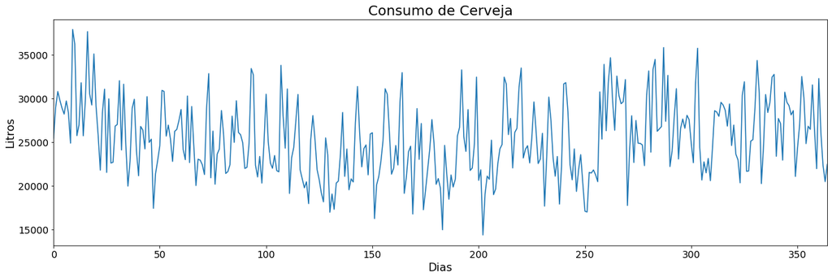

```python
fig, ax = plt.subplots(figsize=(20, 6))

ax.set_title('Consumo de Cerveja', fontsize=20)
ax.set_ylabel('Litros', fontsize=16)
ax.set_xlabel('Dias', fontsize=16)
ax = dados['consumo'].plot(fontsize=14)
```

# Box Plot

[figure not shown]

## Importando biblioteca seaborn

https://seaborn.pydata.org/

O Seaborn é uma biblioteca Python de visualização de dados baseada no matplotlib. Ela fornece uma interface de alto nível para desenhar gráficos estatísticos.

```python
import seaborn as sns
```

## Box plot da variável *dependente* (y)

https://seaborn.pydata.org/generated/seaborn.boxplot.html?highlight=boxplot#seaborn.boxplot

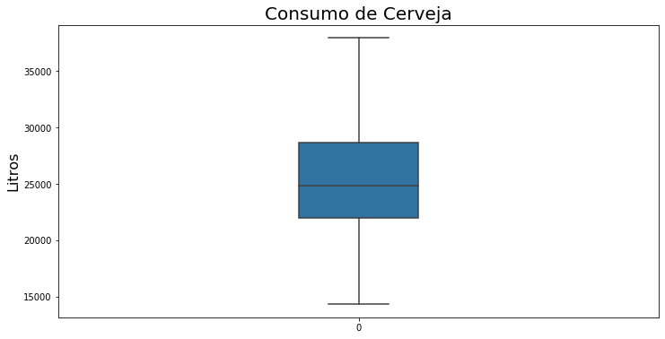

```python
ax = sns.boxplot(data=dados['consumo'], orient='v', width=0.2)
ax.figure.set_size_inches(12, 6)
ax.set_title('Consumo de Cerveja', fontsize=20)
ax.set_ylabel('Litros', fontsize=16)
ax
```

# Box Plot com Duas Variáveis

## Investigando a variável *dependente* (y) segundo determinada característica

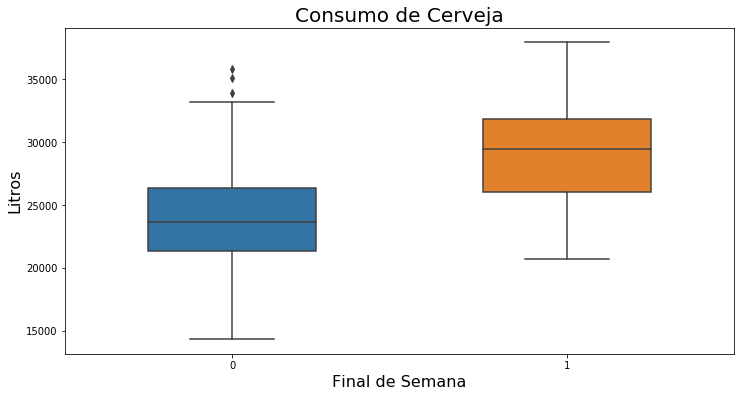

```python
ax = sns.boxplot(y='consumo', x='fds', data=dados, orient='v', width=0.5)
ax.figure.set_size_inches(12, 6)
ax.set_title('Consumo de Cerveja', fontsize=20)
ax.set_ylabel('Litros', fontsize=16)
ax.set_xlabel('Final de Semana', fontsize=16)
ax
```

# Distribuição de Frequências

## Distribuição de frequências da variável *dependente* (y)

https://seaborn.pydata.org/generated/seaborn.distplot.html?highlight=distplot#seaborn.distplot

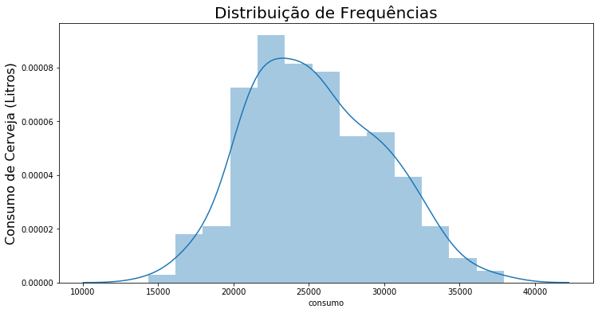

```python
ax = sns.distplot(dados['consumo'])
ax.figure.set_size_inches(12, 6)
ax.set_title('Distribuição de Frequências', fontsize=20)
ax.set_ylabel('Consumo de Cerveja (Litros)', fontsize=16)
ax
```

# Variável Dependente X Variáveis Explicativas (pairplot)

## Gráficos de dispersão entre as variáveis do dataset

## seaborn.pairplot

https://seaborn.pydata.org/generated/seaborn.pairplot.html?highlight=pairplot#seaborn.pairplot

Plota o relacionamento entre pares de variáveis em um dataset.

## Plotando o pairplot fixando somente uma variável no eixo y

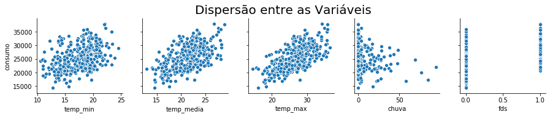

```python
ax = sns.pairplot(dados, y_vars='consumo', x_vars=['temp_min', 'temp_media', 'temp_max', 'chuva', 'fds'])
ax.fig.suptitle('Dispersão entre as Variáveis', fontsize=20, y=1.05)
ax
```

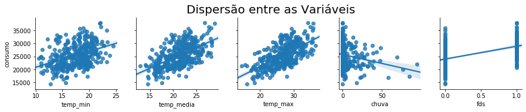

```python
ax = sns.pairplot(dados, y_vars='consumo', x_vars=['temp_min', 'temp_media', 'temp_max', 'chuva', 'fds'], kind='reg')
ax.fig.suptitle('Dispersão entre as Variáveis', fontsize=20, y=1.05)
ax
```

# Variável Dependente X Variáveis Explicativas (lmplot)

## seaborn.lmplot

https://seaborn.pydata.org/generated/seaborn.lmplot.html?highlight=lmplot#seaborn.lmplot

Plota a reta de regressão entre duas variáveis juntamente com a dispersão entre elas.

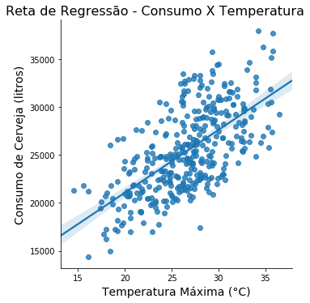

```python
ax = sns.lmplot(x="temp_max", y="consumo", data=dados)
ax.fig.suptitle('Reta de Regressão - Consumo X Temperatura', fontsize=16, y=1.02)
ax.set_xlabels("Temperatura Máxima (°C)", fontsize=14)
ax.set_ylabels("Consumo de Cerveja (litros)", fontsize=14)
ax
```

## Plotando um lmplot utilizando uma terceira variável na análise (tipo I)

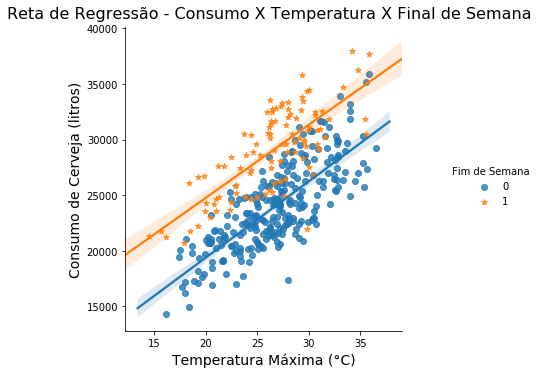

```python
ax = sns.lmplot(x="temp_max", y="consumo", data=dados, hue="fds", markers=['o', '*'], legend=False)
ax.fig.suptitle('Reta de Regressão - Consumo X Temperatura X Final de Semana', fontsize=16, y=1.02)
ax.set_xlabels("Temperatura Máxima (°C)", fontsize=14)
ax.set_ylabels("Consumo de Cerveja (litros)", fontsize=14)
ax.add_legend(title="Fim de Semana")
ax
```

# Estimando um Modelo de Regressão Linear para o Consumo

# Regresão Linear

A análise de regressão diz respeito ao estudo da dependência de uma variável (a variável **dependente**) em relação a uma ou mais variáveis, as variáveis explanatórias, visando estimar e/ou prever o valor médio da primeira em termos dos valores conhecidos ou fixados das segundas.

## scikit-learn (https://scikit-learn.org/stable/)

O *scikit-learn* é um módulo Python especializado em soluções para *machine learning*.

## Importando o *train_test_split* da biblioteca *scikit-learn*

https://scikit-learn.org/stable/modules/generated/sklearn.model_selection.train_test_split.html

```python
from sklearn.model_selection import train_test_split
```

## Criando uma Series (pandas) para armazenar o Consumo de Cerveja (y)

```python
y = dados['consumo']
```

## Criando um DataFrame (pandas) para armazenar as variáveis explicativas (X)

```python
X = dados[['temp_max', 'chuva', 'fds']]
```

## Criando os datasets de treino e de teste

```python
X_train, X_test, y_train, y_test = train_test_split(X, y, test_size=0.3, random_state=2811)
```

## Verificando os tamanhos dos arquivos gerados pela função *train_test_split*

```python
X_train.shape
```

```
(255, 3)
```

```python
X_test.shape
```

```
(110, 3)
```

```python
X_train.shape[0] + X_test.shape[0]
```

```
365
```

[figure not shown]

## Importando *LinearRegression* e *metrics* da biblioteca *scikit-learn*

https://scikit-learn.org/stable/modules/generated/sklearn.linear_model.LinearRegression.html

https://scikit-learn.org/stable/modules/classes.html#regression-metrics

```python
from sklearn.linear_model import LinearRegression
from sklearn import metrics
```

## Instanciando a classe *LinearRegression()*

```python
modelo = LinearRegression()
```

## Utilizando o método *fit()* do objeto "modelo" para estimar nosso modelo linear utilizando os dados de TREINO (y_train e X_train)

https://scikit-learn.org/stable/modules/generated/sklearn.linear_model.LinearRegression.html#sklearn.linear_model.LinearRegression.fit

```python
modelo.fit(X_train, y_train)
```

```
LinearRegression(copy_X=True, fit_intercept=True, n_jobs=None, normalize=False)
```

## Obtendo o coeficiente de determinação (R²) do modelo estimado com os dados de TREINO

https://scikit-learn.org/stable/modules/generated/sklearn.linear_model.LinearRegression.html#sklearn.linear_model.LinearRegression.score

### Coeficiente de Determinação - R²

O coeficiente de determinação (R²) é uma medida resumida que diz quanto a linha de regressão ajusta-se aos dados. É um valor entra 0 e 1.

$$R^2(y, \hat{y}) = 1 - \frac {\sum_{i=0}^{n-1}(y_i-\hat{y}_i)^2}{\sum_{i=0}^{n-1}(y_i-\bar{y}_i)^2}$$

```python
print('R² = {}'.format(modelo.score(X_train, y_train).round(2)))
```

```
R² = 0.73
```

## Gerando previsões para os dados de TESTE (X_test) utilizando o método *predict()* do objeto "modelo"

https://scikit-learn.org/stable/modules/generated/sklearn.linear_model.LinearRegression.html#sklearn.linear_model.LinearRegression.predict

```python
y_previsto = modelo.predict(X_test)
```

## Obtendo o coeficiente de determinação (R²) para as previsões do nosso modelo

https://scikit-learn.org/stable/modules/generated/sklearn.metrics.r2_score.html#sklearn.metrics.r2_score

```python
print('R² = %s' % metrics.r2_score(y_test, y_previsto).round(2))
```

```
R² = 0.69
```

# Obtendo Previsões Pontuais

## Dados de entrada

```python
entrada = X_test[0:1]
entrada
```

|  | temp_max | chuva | fds |
| --- | --- | --- | --- |
| 5 | 30.5 | 12.2 | 0 |

## Gerando previsão pontual

```python
modelo.predict(entrada)[0]
```

```
26094.901775262017
```

## Criando um simulador simples

```python
temp_max=35
chuva=12.2
fds=0
entrada=[[temp_max, chuva, fds]]

print('{0:.2f} litros'.format(modelo.predict(entrada)[0]))
```

```
29176.22 litros
```

# Interpretação dos Coeficientes Estimados

[figure not shown]

## Obtendo o intercepto do modelo

O **intercepto** representa o efeito médio em $Y$ (Consumo de Cerveja) tendo todas as variáveis explicativas excluídas do modelo. De forma mais simples, o **intercepto** representa o efeito médio em $Y$ (Consumo de Cerveja) quando $X_2$ (Temperatura Máxima), $X_3$ (Chuva) e $X_4$ (Final de Semana) são iguais a zero.

```python
modelo.intercept_
```

```
5951.9763393124485
```

```python
type(modelo.intercept_)
```

```
numpy.float64
```

## Obtendo os coeficientes de regressão

Os **coeficientes de regressão** $\beta_2$, $\beta_3$ e $\beta_4$ são conhecidos como **coeficientes parciais de regressão** ou **coeficientes parciais angulares**. Considerando o número de variáveis explicativas de nosso modelo, seu significado seria o seguinte: $\beta_2$ mede a variação no valor médio de $Y$ (Consumo de Cerveja), por unidade de variação em $X_2$ (Temperatura Máxima), mantendo-se os valores de $X_3$ (Chuva) e $X_4$ (Final de Semana) constantes. Em outras palavras, ele nos dá o efeito "direto" ou "líquido" de uma unidade de variação em $X_2$ sobre o valor médio de $Y$, excluídos os efeitos que $X_3$ e $X_4$ possam ter sobre a média de $Y$. De modo análogo podemos interpretar os demais coeficientes de regressão.

```python
modelo.coef_
```

```
array([ 684.73675898,  -60.7824355 , 5401.08333866])
```

```python
type(modelo.coef_)
```

```
numpy.ndarray
```

## Confirmando a ordem das variáveis explicativas no DataFrame

```python
X.columns
```

```
Index(['temp_max', 'chuva', 'fds'], dtype='object')
```

## Criando uma lista com os nomes das variáveis do modelo

```python
index=['Intercepto', 'Temperatura Máxima', 'Chuva (mm)', 'Final de Semana']
```

## Criando um DataFrame para armazenar os coeficientes do modelo

https://docs.scipy.org/doc/numpy/reference/generated/numpy.append.html?#numpy.append

```python
pd.DataFrame(data=np.append(modelo.intercept_, modelo.coef_), index=index, columns=['Parâmetros'])
```

|  | Parâmetros |
| --- | --- |
| Intercepto | 5951.976339 |
| Temperatura Máxima | 684.736759 |
| Chuva (mm) | -60.782435 |
| Final de Semana | 5401.083339 |

## Interpretação dos Coeficientes Estimados

**Intercepto** → Excluindo o efeito das variáveis explicativas ($X_2=X_3=X_4=0$) o efeito médio no Consumo de Cerveja seria de **5951,98 litros**.

**Temperatura Máxima (°C)** → Mantendo-se os valores de $X_3$ (Chuva) e $X_4$ (Final de Semana) constantes, o acréscimo de 1°C na Temperatura Máxima gera uma variação média no Consumo de Cerveja de **684,74 litros**.

**Chuva (mm)** → Mantendo-se os valores de $X_2$ (Temperatura Máxima) e $X_4$ (Final de Semana) constantes, o acréscimo de 1mm de Chuva gera uma variação média no Consumo de Cerveja de **-60,78 litros**.

**Final de Semana (Sim/Não)** → Mantendo-se os valores de $X_2$ (Temperatura Máxima) e $X_3$ (Chuva) constantes, o fato de o dia ser classificado como Final de Semana gera uma variação média no Consumo de Cerveja de **5401,08 litros**.

# Análises Gráficas das Previsões do Modelo

## Gerando as previsões do modelo para os dados de TREINO

```python
y_previsto_train = modelo.predict(X_train)
```

## Gráfico de dispersão entre valor estimado e valor real

https://seaborn.pydata.org/generated/seaborn.scatterplot.html

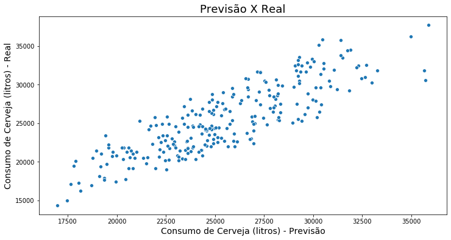

```python
ax = sns.scatterplot(x=y_previsto_train, y=y_train)
ax.figure.set_size_inches(12, 6)
ax.set_title('Previsão X Real', fontsize=18)
ax.set_xlabel('Consumo de Cerveja (litros) - Previsão', fontsize=14)
ax.set_ylabel('Consumo de Cerveja (litros) - Real', fontsize=14)
ax
```

## Obtendo os resíduos

```python
residuo = y_train - y_previsto_train
```

## Gráfico de dispersão entre valor estimado e resíduos

Método informal de verificação da hipótese de variância constante dos resíduos (homocedasticidade)

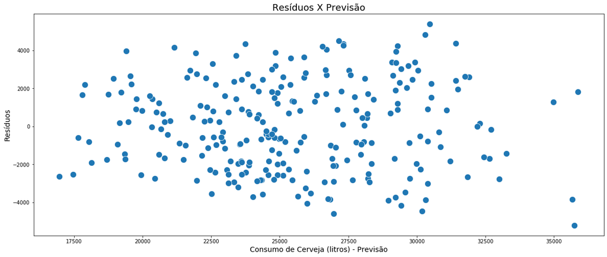

```python
ax = sns.scatterplot(x=y_previsto_train, y=residuo, s=150)
ax.figure.set_size_inches(20, 8)
ax.set_title('Resíduos X Previsão', fontsize=18)
ax.set_xlabel('Consumo de Cerveja (litros) - Previsão', fontsize=14)
ax.set_ylabel('Resíduos', fontsize=14)
ax
```

## Utilizando os resíduos ao quadrado

[figure not shown]

Fonte: Econometria Básica - 5ª edição - Gujarati e Porter

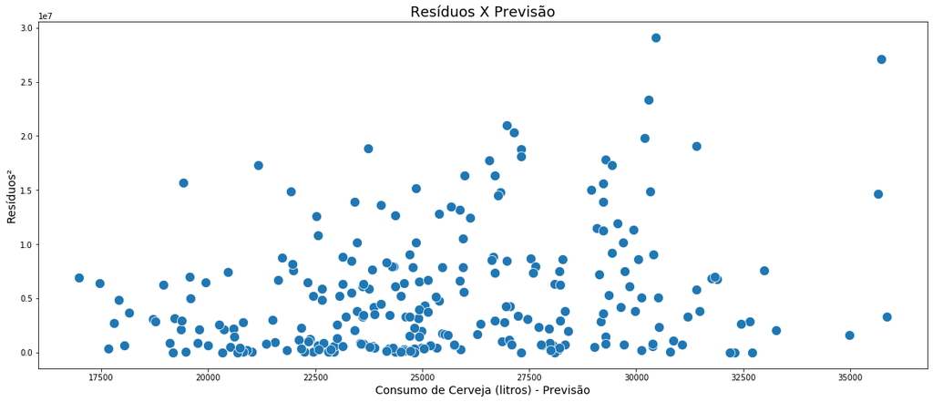

```python
ax = sns.scatterplot(x=y_previsto_train, y=residuo**2, s=150)
ax.figure.set_size_inches(20, 8)
ax.set_title('Resíduos X Previsão', fontsize=18)
ax.set_xlabel('Consumo de Cerveja (litros) - Previsão', fontsize=14)
ax.set_ylabel('Resíduos²', fontsize=14)
ax
```

## Plotando a distribuição de frequências dos resíduos

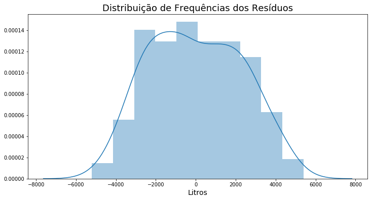

```python
ax = sns.distplot(residuo)
ax.figure.set_size_inches(12, 6)
ax.set_title('Distribuição de Frequências dos Resíduos', fontsize=18)
ax.set_xlabel('Litros', fontsize=14)
ax
```

# Comparando Modelos

## Estimando um novo modelo com a substituição da variável explicativa Temperatura Máxima pela Temperatuda Média

```python
X2 = dados[['temp_media', 'chuva', 'fds']]
```

## Criando os datasets de treino e de teste

```python
X2_train, X2_test, y2_train, y2_test = train_test_split(X2, y, test_size=0.3, random_state=2811)
```

## Instanciando a classe *LinearRegression()*

```python
modelo_2 = LinearRegression()
```

## Utilizando o método *fit()* do objeto "modelo_2" para estimar nosso modelo linear utilizando os dados de TREINO (y2_train e X2_train)

```python
modelo_2.fit(X2_train, y2_train)
```

```
LinearRegression(copy_X=True, fit_intercept=True, n_jobs=None, normalize=False)
```

## Obtendo o coeficiente de determinação (R²) do novo modelo estimado e comparando com o resultado do modelo anterior

```python
print('Modelo com Temp. Média')
print('R² = {}'.format(modelo_2.score(X2_train, y2_train).round(2)))
```

```
Modelo com Temp. Média
R² = 0.66
```

```python
print('Modelo com Temp. Máxima')
print('R² = {}'.format(modelo.score(X_train, y_train).round(2)))
```

```
Modelo com Temp. Máxima
R² = 0.73
```

## Gerando previsões para os dados de TESTE (X_test e X2_test) utilizando o método *predict()* dos objetos "modelo" e "modelo_2"

```python
y_previsto = modelo.predict(X_test)
y_previsto_2 = modelo_2.predict(X2_test)
```

## Obtendo o coeficiente de determinação (R²) para as previsões dos dois modelos

```python
print('Modelo com Temp. Média')
print('R² = {}'.format(metrics.r2_score(y2_test, y_previsto_2).round(2)))
```

```
Modelo com Temp. Média
R² = 0.66
```

```python
print('Modelo com Temp. Máxima')
print('R² = {}'.format(metrics.r2_score(y_test, y_previsto).round(2)))
```

```
Modelo com Temp. Máxima
R² = 0.69
```

# Outras Métricas de Regressão

## Métricas da regressão

fonte: https://scikit-learn.org/stable/modules/model_evaluation.html#regression-metrics

Algumas estatísticas obtidas do modelo de regressão são muito úteis como critério de comparação entre modelos estimados e de seleção do melhor modelo, as principais métricas de regressão que o scikit-learn disponibiliza para modelos lineares são as seguintes:

### Erro Quadrático Médio

Média dos quadrados dos erros. Ajustes melhores apresentam $EQM$ mais baixo.

$$EQM(y, \hat{y}) = \frac 1n\sum_{i=0}^{n-1}(y_i-\hat{y}_i)^2$$

### Raíz do Erro Quadrático Médio

Raíz quadrada da média dos quadrados dos erros. Ajustes melhores apresentam $\sqrt{EQM}$ mais baixo.

$$\sqrt{EQM(y, \hat{y})} = \sqrt{\frac 1n\sum_{i=0}^{n-1}(y_i-\hat{y}_i)^2}$$

## Obtendo métricas para o modelo com Temperatura Média

```python
EQM_2 = metrics.mean_squared_error(y2_test, y_previsto_2).round(2)
REQM_2 = np.sqrt(metrics.mean_squared_error(y2_test, y_previsto_2)).round(2)
R2_2 = metrics.r2_score(y2_test, y_previsto_2).round(2)

pd.DataFrame([EQM_2, REQM_2, R2_2], ['EQM', 'REQM', 'R²'], columns=['Métricas'])
```

|  | Métricas |
| --- | --- |
| EQM | 6060775.46 |
| REQM | 2461.86 |
| R² | 0.66 |

## Obtendo métricas para o modelo com Temperatura Máxima

```python
EQM = metrics.mean_squared_error(y_test, y_previsto).round(2)
REQM = np.sqrt(metrics.mean_squared_error(y_test, y_previsto)).round(2)
R2 = metrics.r2_score(y_test, y_previsto).round(2)

pd.DataFrame([EQM, REQM, R2], ['EQM', 'REQM', 'R²'], columns=['Métricas'])
```

|  | Métricas |
| --- | --- |
| EQM | 5471976.38 |
| REQM | 2339.23 |
| R² | 0.69 |